# Bayesian modeling and prediction for movies

Shaohan Wang

08/24/2020

## Front Matter

```r
# clean up workspace environment
rm(list = ls())
```

## Setup

### Load packages

```r
library(ggplot2)
library(dplyr)
library(statsr)
library(BAS)
library(broom)
library(MASS)
```

### Load data

```r
load("movies.Rdata")
```

### Guiding Question

**Develop a Bayesian regression model to predict audience_score from the following explanatory variables.**

## Part 1: Data

- movies dataset has 651 observations with 32 variables and include randomly sampled movies produced and released before 2016.
- Each case here corresponds to an individual movie with detailed information. This dataset are collected mainly based on observations from `Rotten Tomatoes` and `IMDB` for a random sample of movies which means there is no random assignment, so we `cannot establish causality`. Besides, because the movies included are randomly selected, we can `conclude generalizability` to all of movies produced and released before 2016. However, we may consider convenience sampling bias here because some movies’ information may be much easier to obtain.

## Part 2: Data manipulation

```r
movies <-
  movies %>%
  mutate(feature_film = ifelse(test = title_type == 'Feature Film', 'YES', 'NO'),
         drama = ifelse(genre == 'Drama', 'YES', 'NO'),
         mpaa_rating_R = ifelse(mpaa_rating == 'R', 'YES', 'NO'),
         oscar_season = ifelse(thtr_rel_month == c(10,11,12), 'YES', 'NO'),
         summer_season = ifelse(thtr_rel_month == c(5,6,7,8), 'YES', 'NO'))

names(movies)
```

```
##  [1] "title"            "title_type"       "genre"            "runtime"
##  [5] "mpaa_rating"      "studio"           "thtr_rel_year"    "thtr_rel_month"
##  [9] "thtr_rel_day"     "dvd_rel_year"     "dvd_rel_month"    "dvd_rel_day"
## [13] "imdb_rating"      "imdb_num_votes"   "critics_rating"   "critics_score"
## [17] "audience_rating"  "audience_score"   "best_pic_nom"     "best_pic_win"
## [21] "best_actor_win"   "best_actress_win" "best_dir_win"     "top200_box"
## [25] "director"         "actor1"           "actor2"           "actor3"
## [29] "actor4"           "actor5"           "imdb_url"         "rt_url"
## [33] "feature_film"     "drama"            "mpaa_rating_R"    "oscar_season"
## [37] "summer_season"
```

- create new variables using the `mutate` function in the dplyr package

## Part 3: Exploratory data analysis

```r
# inspect the dataset
glimpse(movies)
```

```
## Rows: 651
## Columns: 37
## $ title            <chr> "Filly Brown", "The Dish", "Waiting for Guffman", ...
## $ title_type       <fct> Feature Film, Feature Film, Feature Film, Feature ...
## $ genre            <fct> Drama, Drama, Comedy, Drama, Horror, Documentary, ...
## $ runtime          <dbl> 80, 101, 84, 139, 90, 78, 142, 93, 88, 119, 127, 1...
## $ mpaa_rating      <fct> R, PG-13, R, PG, R, Unrated, PG-13, R, Unrated, Un...
## $ studio           <fct> Indomina Media Inc., Warner Bros. Pictures, Sony P...
## $ thtr_rel_year    <dbl> 2013, 2001, 1996, 1993, 2004, 2009, 1986, 1996, 20...
## $ thtr_rel_month   <dbl> 4, 3, 8, 10, 9, 1, 1, 11, 9, 3, 6, 12, 1, 9, 6, 8,...
## $ thtr_rel_day     <dbl> 19, 14, 21, 1, 10, 15, 1, 8, 7, 2, 19, 18, 4, 23, ...
## $ dvd_rel_year     <dbl> 2013, 2001, 2001, 2001, 2005, 2010, 2003, 2004, 20...
## $ dvd_rel_month    <dbl> 7, 8, 8, 11, 4, 4, 2, 3, 1, 8, 5, 9, 7, 2, 3, 12, ...
## $ dvd_rel_day      <dbl> 30, 28, 21, 6, 19, 20, 18, 2, 21, 14, 1, 23, 9, 13...
## $ imdb_rating      <dbl> 5.5, 7.3, 7.6, 7.2, 5.1, 7.8, 7.2, 5.5, 7.5, 6.6, ...
```

[output cut: 24 more lines]

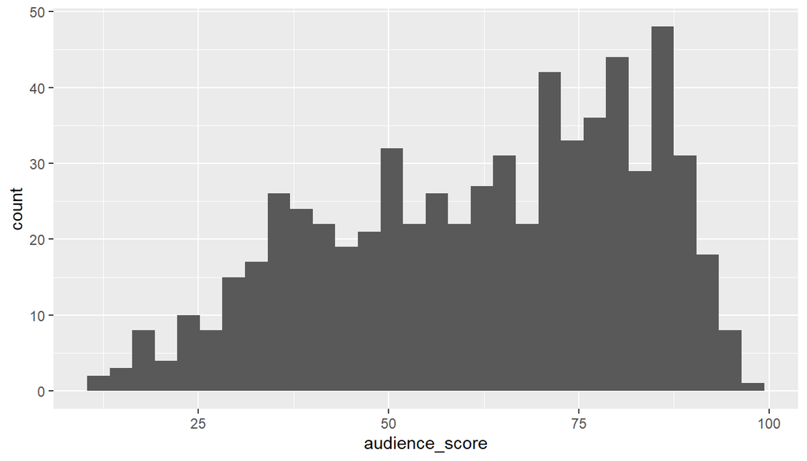

```r
# visualization of audience_score
movies %>%
  ggplot(aes(x = audience_score)) +
  geom_histogram()
```

```r
# summary of audience_score
summary(movies$audience_score)
```

```
##    Min. 1st Qu.  Median    Mean 3rd Qu.    Max.
##   11.00   46.00   65.00   62.36   80.00   97.00
```

```r
table(movies$audience_score)
```

```
##
## 11 13 14 15 17 18 19 21 22 23 24 25 26 27 28 29 30 31 32 33 34 35 36 37 38 39
##  1  1  2  1  3  1  4  1  3  2  5  3  2  3  3  6  3  6  4  7  6 13  4  9  8  5
## 40 41 42 43 44 45 46 47 48 49 50 51 52 53 54 55 56 57 58 59 60 61 62 63 64 65
## 11  8  5  9 11  8  9  6  6 17  6  9 11  4  7 15  5  6  7  9  6  9  8 10 10 12
## 66 67 68 69 70 71 72 73 74 75 76 77 78 79 80 81 82 83 84 85 86 87 88 89 90 91
##  9  7  8  7 14 13 15 11 11 11 13  9 14 14 12 18 10 10  9 15 16 17  8 17  6  7
## 92 93 94 95 96 97
##  7  4  5  2  1  1
```

## Part 4: Modeling

```r
movies <- na.omit(movies) # exclude NA

# set the model by applying BMA to the audience_score using all potential predictors
bma_movies <- bas.lm(audience_score ~ feature_film + drama + runtime + mpaa_rating_R + thtr_rel_year + oscar_season + summer_season + imdb_rating + imdb_num_votes + critics_score + best_pic_nom + best_pic_win + best_actor_win + best_actress_win + best_dir_win + top200_box, data = movies, prior = 'BIC', modelprior = uniform())

# Top 5 most probably models
summary(bma_movies) # we will pick the best model (model1) with highest posterior prob and highest Bayes factor
```

```
##                     P(B != 0 | Y)    model 1       model 2       model 3
## Intercept              1.00000000     1.0000     1.0000000     1.0000000
## feature_filmYES        0.05890089     0.0000     0.0000000     0.0000000
## dramaYES               0.04501771     0.0000     0.0000000     0.0000000
## runtime                0.51597119     1.0000     0.0000000     0.0000000
## mpaa_rating_RYES       0.16624831     0.0000     0.0000000     0.0000000
## thtr_rel_year          0.08092839     0.0000     0.0000000     0.0000000
## oscar_seasonYES        0.06507927     0.0000     0.0000000     0.0000000
## summer_seasonYES       0.09785966     0.0000     0.0000000     0.0000000
## imdb_rating            1.00000000     1.0000     1.0000000     1.0000000
## imdb_num_votes         0.06242457     0.0000     0.0000000     0.0000000
## critics_score          0.92375311     1.0000     1.0000000     1.0000000
## best_pic_nomyes        0.13158359     0.0000     0.0000000     0.0000000
## best_pic_winyes        0.04078454     0.0000     0.0000000     0.0000000
## best_actor_winyes      0.11605692     0.0000     0.0000000     0.0000000
## best_actress_winyes    0.14953915     0.0000     0.0000000     1.0000000
## best_dir_winyes        0.06705801     0.0000     0.0000000     0.0000000
## top200_boxyes          0.04857572     0.0000     0.0000000     0.0000000
## BF                             NA     1.0000     0.8715404     0.2048238
## PostProbs                      NA     0.1528     0.1332000     0.0313000
## R2                             NA     0.7483     0.7455000     0.7470000
## dim                            NA     4.0000     3.0000000     4.0000000
## logmarg                        NA -3434.7520 -3434.8894481 -3436.3375603
##                           model 4       model 5
## Intercept               1.0000000     1.0000000
## feature_filmYES         0.0000000     0.0000000
## dramaYES                0.0000000     0.0000000
## runtime                 1.0000000     1.0000000
## mpaa_rating_RYES        1.0000000     0.0000000
## thtr_rel_year           0.0000000     0.0000000
## oscar_seasonYES         0.0000000     0.0000000
## summer_seasonYES        0.0000000     0.0000000
## imdb_rating             1.0000000     1.0000000
## imdb_num_votes          0.0000000     0.0000000
## critics_score           1.0000000     1.0000000
## best_pic_nomyes         0.0000000     1.0000000
## best_pic_winyes         0.0000000     0.0000000
## best_actor_winyes       0.0000000     0.0000000
## best_actress_winyes     0.0000000     0.0000000
## best_dir_winyes         0.0000000     0.0000000
## top200_boxyes           0.0000000     0.0000000
## BF                      0.2039916     0.1851908
## PostProbs               0.0312000     0.0283000
## R2                      0.7496000     0.7495000
## dim                     5.0000000     5.0000000
## logmarg             -3436.3416317 -3436.4383237
```

```r
# set our final model
bma_movies_final <- bas.lm(audience_score ~ runtime + imdb_rating + critics_score, data = movies, prior = 'BIC', modelprior = uniform()) # we include the predictors which provide the best prediction

summary(bma_movies_final) # check our final model with all predictors
```

```
##               P(B != 0 | Y)    model 1       model 2       model 3
## Intercept         1.0000000     1.0000     1.0000000  1.000000e+00
## runtime           0.5396634     1.0000     0.0000000  1.000000e+00
## imdb_rating       1.0000000     1.0000     1.0000000  1.000000e+00
## critics_score     0.9323343     1.0000     1.0000000  0.000000e+00
## BF                       NA     1.0000     0.8715404  8.330447e-02
## PostProbs                NA     0.4982     0.4342000  4.150000e-02
## R2                       NA     0.7483     0.7455000  7.436000e-01
## dim                      NA     4.0000     3.0000000  3.000000e+00
## logmarg                  NA -3434.7520 -3434.8894481 -3.437237e+03
##                     model 4       model 5
## Intercept      1.000000e+00  1.000000e+00
## runtime        0.000000e+00  0.000000e+00
## imdb_rating    1.000000e+00  0.000000e+00
## critics_score  0.000000e+00  1.000000e+00
## BF             5.252575e-02  2.820632e-92
## PostProbs      2.620000e-02  0.000000e+00
## R2             7.405000e-01  4.921000e-01
## dim            2.000000e+00  2.000000e+00
## logmarg       -3.437698e+03 -3.645553e+03
```

- We set our Bayesian multiple regression model with the possible predictors by Bayesian Model Average based on prior on Bayesoan Information Criterion(BIC). Then, we use `summary` function to find the best 5 models with highest posterior prob and highest Bayes factors. We pick the best one with the predictors which have highest posterior prob to be included in as our final model and drop other statistically insignificant regressors. Then, we also use the `summary` table to check the posterior prob and Bayes factors and thus, find out that our current model has the best goodness of fit.

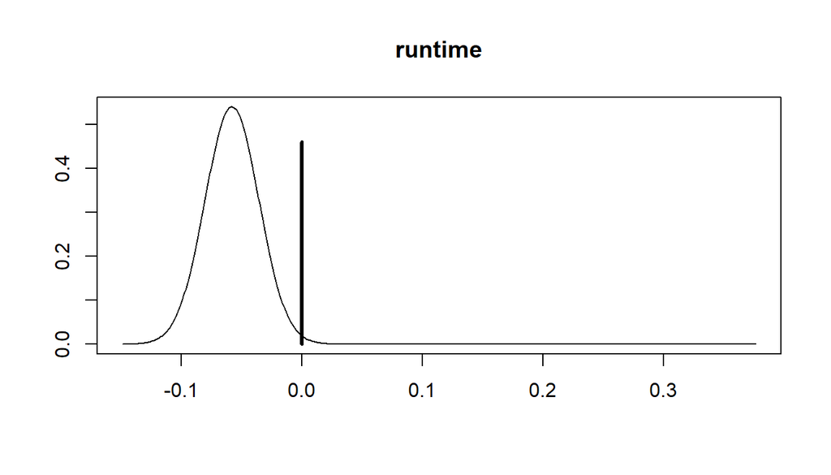

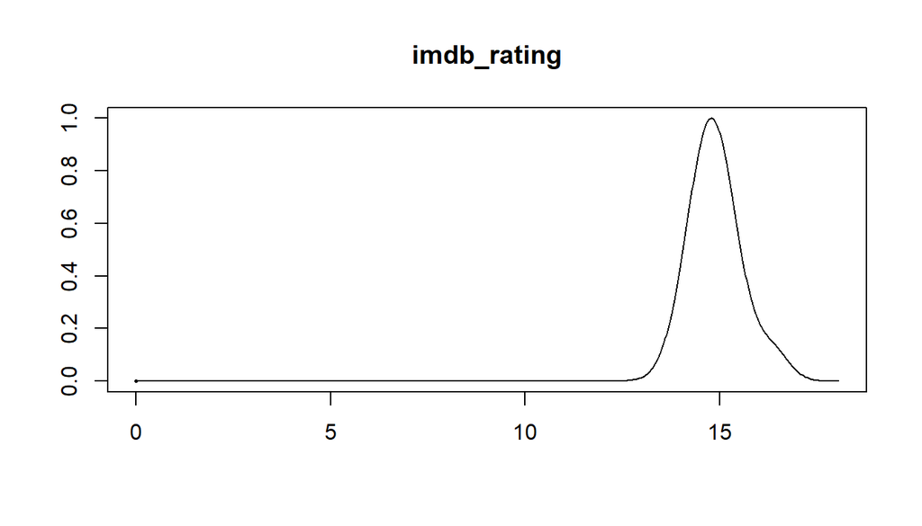

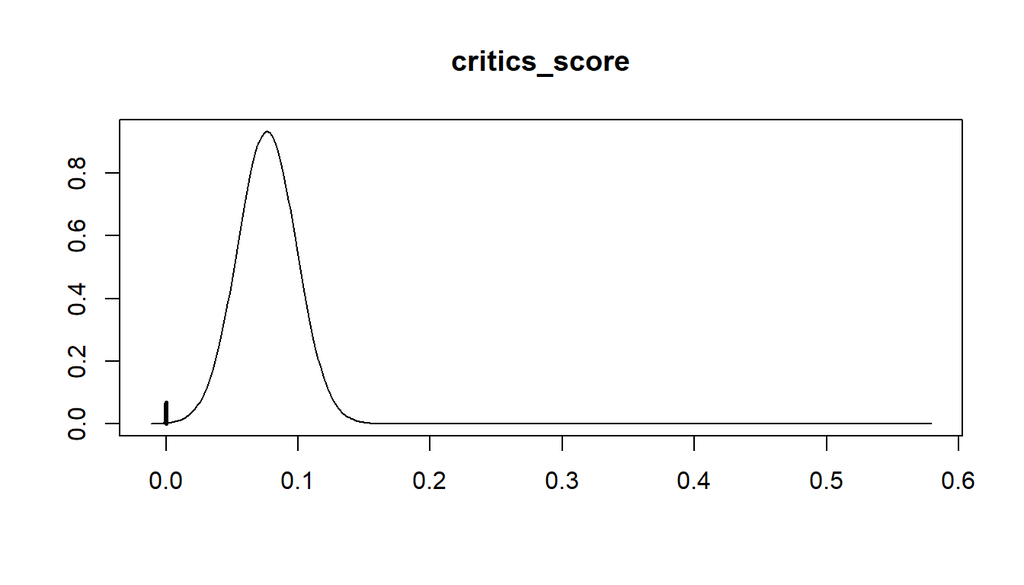

```r
# Obtain the coefficients from the model `bma_movies_final`
coef_bma_movies_final <- coefficients(bma_movies_final)

plot(coef_bma_movies_final, subset = c(2,3,4), ask = FALSE) # plot the posterior distribution of coefficients of our predictors for diagnostic
```

```r
coef(bma_movies_final) %>%
  confint() # the coefficients with 95% credible intervals
```

```
##                      2.5%      97.5%        beta
## Intercept     61.39775082 63.0171617 62.21001616
## runtime       -0.08943506  0.0000000 -0.03138428
## imdb_rating   13.55627057 16.4745298 14.89079350
## critics_score  0.00000000  0.1125703  0.07128748
## attr(,"Probability")
## [1] 0.95
## attr(,"class")
## [1] "confint.bas"
```

## Part 5: Prediction

```r
# Pick a movie from 2016
Zootopia <- data.frame(runtime = 108, imdb_rating = 8.0, critics_score = 98)

# do the prediction by our model
predict(bma_movies_final, Zootopia)
```

```
## $fit
## [1] 87.60678
##
## $Ybma
##          [,1]
## [1,] 87.60678
##
## $Ypred
##          [,1]
## [1,] 87.82158
## [2,] 87.46689
## [3,] 87.07810
## [4,] 86.67691
## [5,] 82.48372
## [6,] 82.20609
## [7,] 62.52195
## [8,] 62.21002
##
## $postprobs
## [1]  4.981641e-01  4.341702e-01  4.149929e-02  2.616645e-02  1.405138e-92
## [6]  6.957269e-93 5.486013e-178 2.963655e-182
##
## $se.fit
## NULL
##
## $se.pred
## NULL
##
## $se.bma.fit
## NULL
##
## $se.bma.pred
## NULL
##
## $df
## [1] 615 616 616 617 617 616 617 618
##
## $best
## [1] 4 3 7 5 8 6 2 1
##
```

[output cut: 19 more lines]

```
## $bestmodel[[7]]
## [1] 0 1
##
## $bestmodel[[8]]
## [1] 0
##
##
## $best.vars
## [1] "Intercept"     "runtime"       "imdb_rating"   "critics_score"
##
## $estimator
## [1] "BMA"
##
## attr(,"class")
## [1] "pred.bas"
```

- I choose Zootopia(2016) to do the prediction by using our bayesian multiple regression model by Bayesian Model Average based on prior on Bayesoan Information Criterion(BIC). The fitted value I obtain is around **87.61**. The actual audience score is **92** which is a little higher than our predicted audience score on Rotten Tomatoes.

## Part 6: Conclusion

- In conclusion, there is definitely an association among audience scores on Rotten Tomatoes and runtime of movie, ratings on IMDB, critics score on Rotten Tomatoes. Because of the low posterior prob and Bayes factors for our original explanatory variables, I decided to exclude them when building the final Bayesian multiple regression model based on Bayesian Model Averaging.
- However, our final model still presents a shortcoming because there is a noticeable difference between our predicted audience score and the actual audience score on Rotten Tomatoes. I believe one of the solutions is to add more appropriate and statistically significant explanatory variables which will help the full model yield smaller BIC and better goodness of fit with higher complexity.